# Experiment 3

## KNMI station vs. KNMI radar vs. GPM-IMERG satellite over Netherlands

### Data

**Satellite data (gpm)**

- Dataset: GPM IMERG Final Precipitation
- Temporal Resolution: 1 day
- Spatial Resolution: 0.1 deg
- Date Range: 2014-03-12 to 2018-05-15
- Spatial Region: latitude: 50.75, 53.55, longitude: 3.45, 7.15
- Variables: precipitationCal
- Format: netCDF 4
- Variables: gpm_d_cells (coordinates) & gpm_d_prcp (values) in *experiment_3.rdata*.
- IDs: gpm_1
- Size: 1681652 total values, over 1102 grid cells
- Downloaded from: https://climexp.knmi.nl/select.cgi?id=312456c83e660703df1bfea9ba4fba50&field=imerg_daily

**Instrumental data (knmi)**

- Dataset: 240 homogenised stations 1951-now (raw)
- Temporal Resolution: 24hours
- Spatial Resolution: -
- Date Range: 1950-12-31 to 2018-04-29
- Spatial Region: latitude: 50.78, 53.48, longitude: 3.4, 7.11
- Format: *.txt
- IDs: 010
- Size: 5902080 total values, over 240 stations
- Downloaded from: https://climexp.knmi.nl/PhomNL.cgi?id=312456c83e660703df1bfea9ba4fba50

**Radar data (knmi)**

- Dataset: RAD_NL25_RAC_MFBS_24H_NC
- Temporal Resolution: 24hours
- Spatial Resolution: 1x1km
- Date Range: 2015-10-01 to 2016-09-29
- Spatial Region: latitude: 50.76, 53.56, longitude: 3.37, 7.22
- Format: *.nc
- Variables:
- IDs: rdr_1
- Size: 12400443 total values, over 30816 grid cells
- Downloaded from: https://climexp.knmi.nl/select.cgi?id=312456c83e660703df1bfea9ba4fba50&field=knmi_radar_daily

### Code structure

*data_import.R* : Import and prepare station, radar and satellite data for the Netherlands. Each pair of data (values and coordinates) is then saved to **experiment_3_raw.rdata**.

*comparison_prep.R* : Prepare datasets for comparison: align datasets in time and space and save them to **experiment_3_main.rdata**, find wet days and save them to **experiment_3_wdays.rdata**.

*comparison_eda.R* : Exploratory analysis contains comparison of first moments, extreme values (gumbel probability), wet days (intersection plots).

*comparison_agg.R* : Aggregation of rain events over space and time.

### Exploratory Data Analysis

*Results of comparison_eda.R*

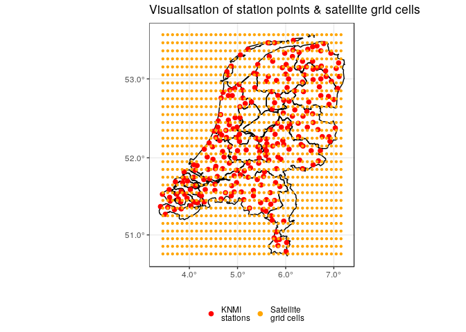

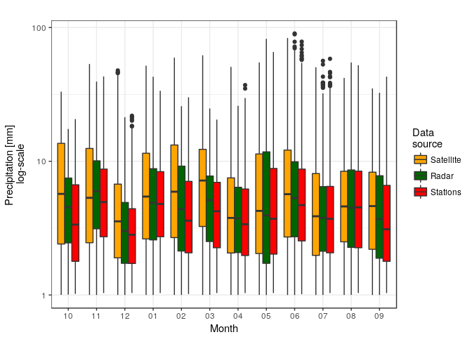

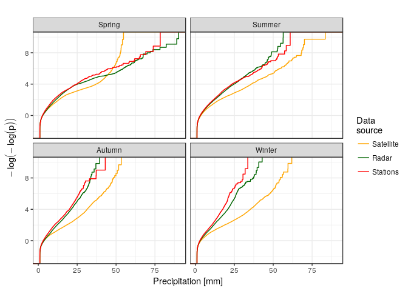

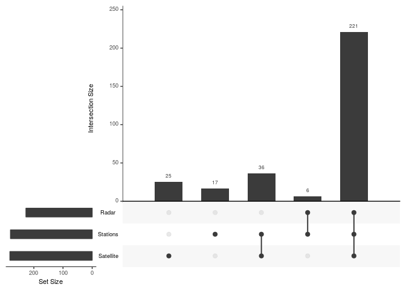

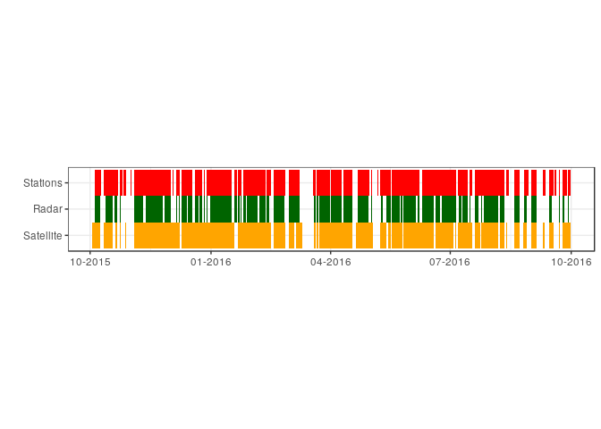

|  | Satellite | Radar | Stations |
| --- | --- | --- | --- |
| Mean | 7.96 | 6.22 | 5.6 |
| Minimum | 1 | 1 | 1.01 |
| 5% Quantile | 1.2 | 1.2 | 1.22 |
| 25% Quantile | 2.35 | 2.3 | 2.16 |
| Median | 4.86 | 4.51 | 4 |
| 75% Quantile | 10.33 | 8.26 | 7.33 |
| 95% Quantile | 26.16 | 16.9 | 15.23 |
| Maximum | 83.45 | 90.24 | 78.4 |
| Standard Deviation | 8.34 | 5.63 | 5.12 |
| Coeficient of Variation | 1.05 | 0.91 | 0.91 |

[output cut: 1 more lines]

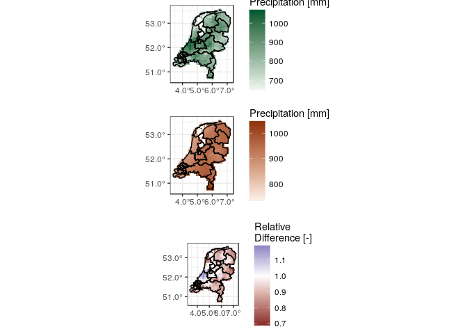